# Data Analysis in R

Advanced Modeling Examples

Conor Fair

2025-03-11

## Advanced Modeling Examples

There are three types of advanced models I would like to cover that I believe that Entomologists either use often that has potential complications within the statistical analysis, or types of analyses that are rarely considered but that fit Entomological data very well.

## Zero-Inflation

When we discussed the webworm data we fit with a generalised linear model using a negative binomial distribution I made a note that there were several zeros observed that could be problematic for count models. This type of issue is known as zero-inflation. There is a specific type of mixture model that is used to model data that meet these conditions, and you can review other [sources](https://www.highstat.com/index.php/books2?view=article&id=23&catid=18) to understand the theory behind these models. We will rather review the applied basics of diagnosing zero-inflation in data and discuss some simple steps to adapt your model to produce un-biased estimates.

#### Loading the Data

We will re-use the webworm data for this exercise

```r
library(readr)
library(here)
library(tidyverse)
Webworms <- read_csv(here("data", "Overdispersion.csv"), col_types = "dddffff")
str(Webworms)
```

```
## spc_tbl_ [1,300 × 7] (S3: spec_tbl_df/tbl_df/tbl/data.frame)
##  $ row  : num [1:1300] 1 2 3 4 5 6 7 8 9 10 ...
##  $ col  : num [1:1300] 1 1 1 1 1 1 1 1 1 1 ...
##  $ y    : num [1:1300] 1 0 1 3 6 0 2 2 1 3 ...
##  $ block: Factor w/ 13 levels "B1","B2","B3",..: 1 1 1 1 1 2 2 2 2 2 ...
##  $ trt  : Factor w/ 4 levels "T1","T2","T3",..: 1 1 1 1 1 1 1 1 1 1 ...
##  $ spray: Factor w/ 2 levels "N","Y": 1 1 1 1 1 1 1 1 1 1 ...
##  $ lead : Factor w/ 2 levels "N","Y": 1 1 1 1 1 1 1 1 1 1 ...
##  - attr(*, "spec")=
##   .. cols(
##   ..   row = col_double(),
##   ..   col = col_double(),
##   ..   y = col_double(),
##   ..   block = col_factor(levels = NULL, ordered = FALSE, include_na = FALSE),
##   ..   trt = col_factor(levels = NULL, ordered = FALSE, include_na = FALSE),
##   ..   spray = col_factor(levels = NULL, ordered = FALSE, include_na = FALSE),
##   ..   lead = col_factor(levels = NULL, ordered = FALSE, include_na = FALSE)
##   .. )
##  - attr(*, "problems")=<externalptr>
```

#### Visualizing the Data

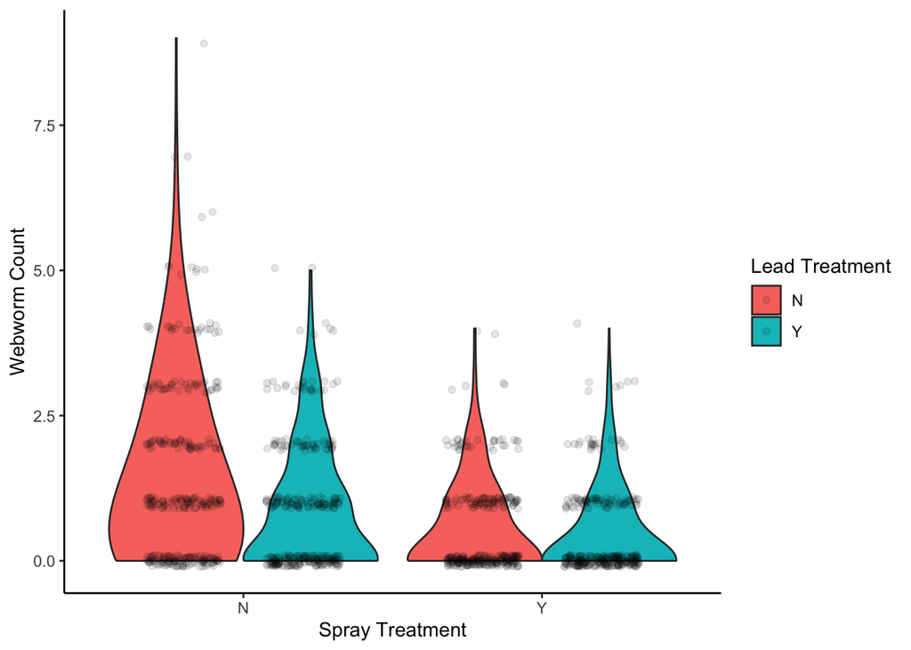

```r
ggplot(Webworms, aes(x = spray, y = y, fill = lead)) +
  geom_violin(scale = "width", adjust = 2) +
  geom_point(position = position_jitterdodge(jitter.width = 0.5, jitter.height = 0.1, dodge.width = 0.8), alpha = 0.1) +
  labs(x = "Spray Treatment", y = "Webworm Count", fill = "Lead Treatment") +
  theme_classic()
```

Notice the clusters of zero observations for each spray and lead treatment combination. We initially fit a glm with a poisson distribution and determined that there was significant evidence of overdispersion. This is an important first step compared to testing for zero-inflation first. Zero-inflation can be mistaken for overdispersion. In the absence of overdispersion a glm fit with a poisson distribution can then be tested for zero-inflation. Furthermore, glm models fit with a negative binomial distribution can also have zero-inflation.

We will now fit the glm with a negative binomial distribution and test for zero-inflation.

#### Fit Linear Model and Test Assumptions

```r
library(glmmTMB)
library(DHARMa)
```

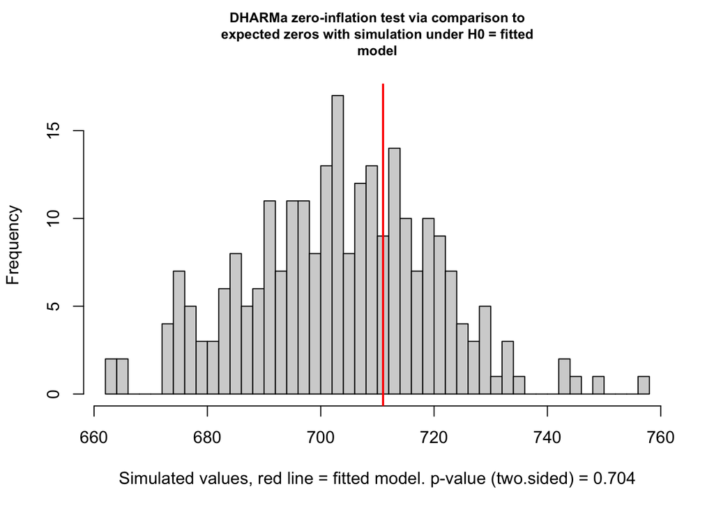

```
##
##  DHARMa zero-inflation test via comparison to expected zeros with
##  simulation under H0 = fitted model
##
## data:  simulationOutput
## ratioObsSim = 1.0101, p-value = 0.704
## alternative hypothesis: two.sided
```

```r
mod_nb <- glmmTMB(y ~ spray * lead, data = Webworms, family = "nbinom2")

testZeroInflation(mod_nb)
```

These results illustrate a crucial element about testing for zero-inflation. While a visual assessment of the raw data may suggest a potential for zero-inflation, you must test the number of observed zeros compared to the number of expected zeros given the model estimates.

Here is an example of a data set that has zero-inflation.

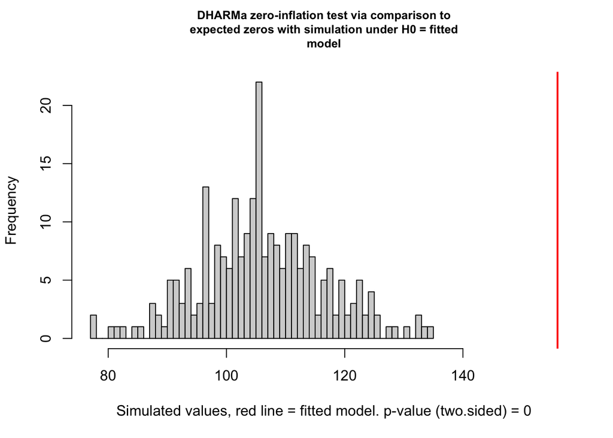

```
##
##  DHARMa zero-inflation test via comparison to expected zeros with
##  simulation under H0 = fitted model
##
## data:  simulationOutput
## ratioObsSim = 1.4645, p-value < 2.2e-16
## alternative hypothesis: two.sided
```

```r
# You can load example data directly from a package
data(Owls, package = "glmmTMB")

owls_nb1 <- glmmTMB(SiblingNegotiation ~ FoodTreatment * SexParent +
                                    (1|Nest) + offset(log(BroodSize)),
              family = nbinom2(), data = Owls)

testZeroInflation(owls_nb1)
```

Here we see a significant result from the `testZeroInflation()` function.

Note: offset is another argument you can use with count models where you have an unequal level of effort used to observe the counts. In this scenario the probability of observing the response (i.e., sibling negotiation) is more likely when there is a larger brood size. So the log of the brood size is included as an offset term. The log of the brood size is used because the log is used as the link function for this model.

## Hazard Models - Time-to-Event Models

Once you recognize the characteristics of this type of data, you will be surprised how often you see it in entomology research. This type of model was originally developed in cancer research where they modeled how long it took for a death to occur. In many applied settings, especially with pest insects, data is collected on how long it takes for insects to die under various conditions. You can also model how long it takes for other events to occur - it doesn’t always have to be death or event a seemingly “negative” outcome. You are modeling how long it takes for an event to occur.

This example data looks at the survival of old and young birds. These data look at 50 individual birds.

```r
x <- "https://raw.githubusercontent.com/Conorfair/ENTO_8900/main/Duck%20survival.csv"
Birdsurv <- read.csv(x)

str(Birdsurv)
```

```
## 'data.frame':    50 obs. of  4 variables:
##  $ Bird     : int  1 2 3 4 5 6 7 8 9 10 ...
##  $ Time     : int  2 6 6 7 13 14 16 16 17 17 ...
##  $ Indicator: int  1 0 0 1 1 0 0 1 0 1 ...
##  $ Age      : int  1 0 1 0 1 0 1 1 1 1 ...
```

```r
Birdsurv$Age <- as.factor(Birdsurv$Age)
Birdsurv$Age <- factor(Birdsurv$Age, levels = c("0", "1"), labels = c("Young", "Old"))
table(Birdsurv$Age)
```

```
##
## Young   Old
##    31    19
```

```r
str(Birdsurv)
```

```
## 'data.frame':    50 obs. of  4 variables:
##  $ Bird     : int  1 2 3 4 5 6 7 8 9 10 ...
##  $ Time     : int  2 6 6 7 13 14 16 16 17 17 ...
##  $ Indicator: int  1 0 0 1 1 0 0 1 0 1 ...
##  $ Age      : Factor w/ 2 levels "Young","Old": 2 1 2 1 2 1 2 2 2 2 ...
```

Initial visualization of the data can be done using Kaplan-Meier curves. A simple look into these data compares the survival functions between age of birds

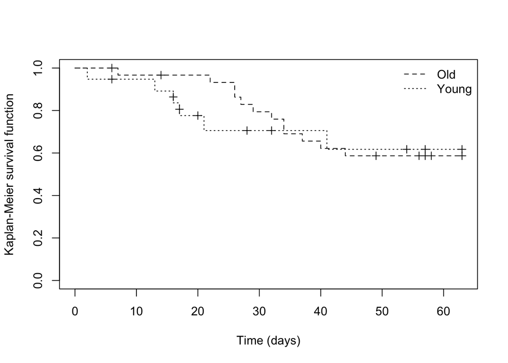

```r
library(survival)
Surv_function_KM <- survfit(Surv(Time, Indicator) ~ Age, data = Birdsurv)
plot(Surv_function_KM, xlab = "Time (days)", lty = c(2, 3), ylab = "Kaplan-Meier survival function", mark.time = TRUE)
legend("topright", bty = "n", c("Old", "Young"), lty = 2:3)
```

Further analysis can be done using cox-proportional hazard models - where hazard models get their names.

```r
Birdsurvcox <- coxph(Surv(Time, Indicator) ~ Age, data = Birdsurv, model = TRUE)
summary(Birdsurvcox)
```

```
## Call:
## coxph(formula = Surv(Time, Indicator) ~ Age, data = Birdsurv,
##     model = TRUE)
##
##   n= 50, number of events= 18
##
##          coef exp(coef) se(coef)     z Pr(>|z|)
## AgeOld 0.1411    1.1515   0.5018 0.281    0.779
##
##        exp(coef) exp(-coef) lower .95 upper .95
## AgeOld     1.152     0.8684    0.4306     3.079
##
## Concordance= 0.538  (se = 0.06 )
## Likelihood ratio test= 0.08  on 1 df,   p=0.8
## Wald test            = 0.08  on 1 df,   p=0.8
## Score (logrank) test = 0.08  on 1 df,   p=0.8
```

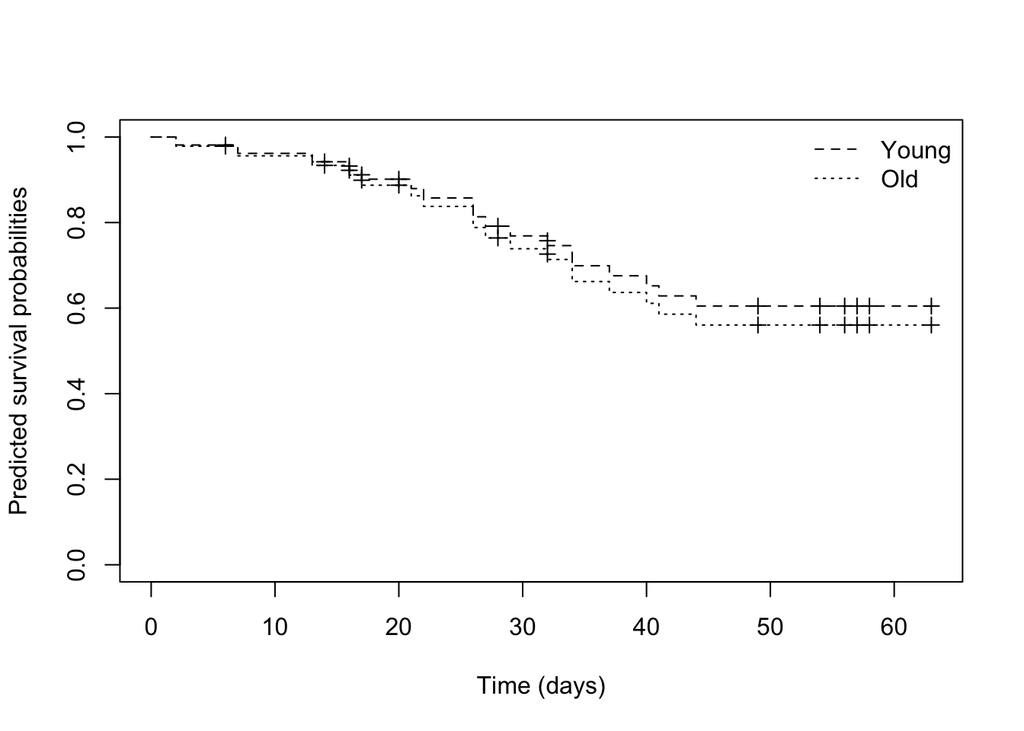

```r
# Likelihood ratio test= 0.08 on 1 df, p=0.7804
# Compares the fit of the model to the fit of the null model by estimating the ratio of their likelihoods (or difference in log likelihoods).
# Wald test = 0.08 on 1 df, p=0.7786
# Tests how far the estimated parameters are from zero.

#Model's Predicted Survival Probabilities (Fig. 4C)
Surv_function <- survfit(Birdsurvcox, newdata = data.frame(Age = c("Young", "Old")))$surv #survival function
plot(survfit(Birdsurvcox, newdata = data.frame(Age = c("Young", "Old"))), lty = c(2,3), xlab = "Time (days)",
     ylab = "Predicted survival probabilities", mark.time = TRUE)
legend("topright", bty = "n", c("Young", "Old"), lty = 2:3)
```

```r
#Testing the proportional hazard assumption - assumption is not violated (chi^2=2.85,p=0.092)
cox.zph(Birdsurvcox)
```

```
##        chisq df     p
## Age     2.85  1 0.092
## GLOBAL  2.85  1 0.092
```

One of the major assumptions of the cox proportional hazard model is the proportional hazard assumption. The `cox.zph()` function tests this assumption. In the event that this assumption is violated you should review the help files or consider another model. Another consideration is the presence of ties in the order of when events occur. Again, review the help files to learn more about how to handle this issue. My goal is to present this type of analysis while also highlighting potential red flags that could come up.

## Mixed Effects Models - Extension for Repeated Measures

We discussed another assumption of linear models - the assumption that errors were independent. That is not always the case, and there can be many causes of this lack of independence. A common source comes from the experimental design and is also known as split-plot designs. In a split-plot design the randomization of a treatment level (sub-plot) is dependent on the level of another effect (whole-plot). Another scenario where there is a lack of independence is when you have repeated observations of experimental units. If you have plots where you are measuring insect activity multiple times (>2) throughout a period a time, then these observations are not independent and the assumptions of the linear model are violated. Both these issues can be addressed using mixed effects models.

The specification of random effects in R follows a predictable syntax for related packages. The `glmmTMB` package is gaining popularity in ecology- and agriculture-related fields. Here is a [reference](https://bbolker.github.io/mixedmodels-misc/glmmFAQ.html) for how to specify random effects along with other helpful guidelines for generalized linear mixed effects models.

## Split-Plot Design - Multiple Random Intercepts

#### Review the Experimental Design

You may recognize this model structure from the examples used in the split-plot design lecture.

The data for this example is a slightly modified version of the yield (kg/ha) trial laid out as a split-plot design (Gomez & Gomez 1984). The trial had 4 genotypes (G), 6 nitrogen levels (N or n_amount) with 3 complete replicates (rep) and 6 incomplete blocks (mainplot) within each replicate.

#### Importing the Data

```r
Split_plot <- read_csv(here("data", "Split_Plot_Design.csv"), col_types = "dddffffd")
str(Split_plot)
```

```
## spc_tbl_ [72 × 8] (S3: spec_tbl_df/tbl_df/tbl/data.frame)
##  $ yield   : num [1:72] 4520 5598 6192 8542 5806 ...
##  $ row     : num [1:72] 4 2 1 2 2 1 2 4 3 4 ...
##  $ col     : num [1:72] 1 2 3 4 5 6 1 2 3 4 ...
##  $ rep     : Factor w/ 3 levels "rep1","rep2",..: 1 1 1 1 1 1 1 1 1 1 ...
##  $ mainplot: Factor w/ 18 levels "mp1","mp2","mp3",..: 1 2 3 4 5 6 1 2 3 4 ...
##  $ G       : Factor w/ 4 levels "A","B","C","D": 1 1 1 1 1 1 2 2 2 2 ...
##  $ N       : Factor w/ 6 levels "N1","N2","N4",..: 1 2 3 4 5 6 1 2 3 4 ...
##  $ n_amount: num [1:72] 0 60 120 180 90 150 0 60 120 180 ...
##  - attr(*, "spec")=
##   .. cols(
##   ..   yield = col_double(),
##   ..   row = col_double(),
##   ..   col = col_double(),
##   ..   rep = col_factor(levels = NULL, ordered = FALSE, include_na = FALSE),
##   ..   mainplot = col_factor(levels = NULL, ordered = FALSE, include_na = FALSE),
##   ..   G = col_factor(levels = NULL, ordered = FALSE, include_na = FALSE),
##   ..   N = col_factor(levels = NULL, ordered = FALSE, include_na = FALSE),
##   ..   n_amount = col_double()
##   .. )
##  - attr(*, "problems")=<externalptr>
```

#### Exploring the Data

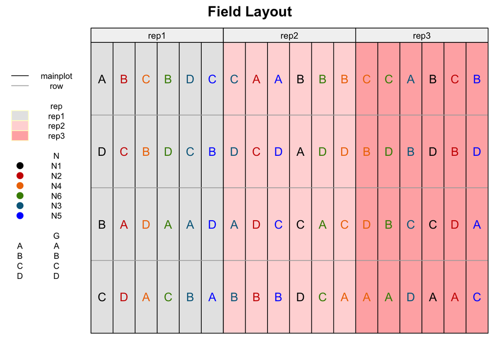

```r
library(desplot)
desplot(data = Split_plot,
        form = rep ~ col + row | rep, # fill color per rep, headers per rep
        text = G, cex = 1, shorten = "no", # show genotype names per plot
        col = N, # color of genotype names for each N-level
        out1 = mainplot, out1.gpar = list(col = "black"), # lines between mainplots
        out2 = row, out2.gpar = list(col = "darkgrey"), # lines between rows
                main = "Field Layout",show.key = T,key.cex = 0.7) # formatting
```

#### Fitting ANOVA Models with R and Assumptions

```r
mod_re <- lmerTest::lmer(yield ~ N * G + (1|rep) + (1|rep : mainplot), data = Split_plot) #(1|rep/mainplot) same syntax for lmer function - glmmTMB may produce different result
```

```
## boundary (singular) fit: see help('isSingular')
```

```r
#isSingular warning message tells us that one of the random effects is accounting for very little variation - since this random effect is related to the experimental design we will NOT ignore it
summary(mod_re)
```

```
## Linear mixed model fit by REML. t-tests use Satterthwaite's method [
## lmerModLmerTest]
## Formula: yield ~ N * G + (1 | rep) + (1 | rep:mainplot)
##    Data: Split_plot
##
## REML criterion at convergence: 780.8
##
## Scaled residuals:
##     Min      1Q  Median      3Q     Max
## -1.8506 -0.5356 -0.1311  0.4778  1.9272
##
## Random effects:
##  Groups       Name        Variance  Std.Dev.
##  rep:mainplot (Intercept) 5.086e+04 225.51172
##  rep          (Intercept) 3.070e-03   0.05541
##  Residual                 3.494e+05 591.13579
## Number of obs: 72, groups:  rep:mainplot, 18; rep, 3
##
## Fixed effects:
##             Estimate Std. Error       df t value Pr(>|t|)
## (Intercept)  4252.67     365.28    45.78  11.642 2.79e-15 ***
## NN2          1419.33     516.59    45.78   2.748  0.00856 **
## NN4          2480.00     516.59    45.78   4.801 1.73e-05 ***
## NN6          4448.00     516.59    45.78   8.610 3.94e-11 ***
## NN3          2147.33     516.59    45.78   4.157  0.00014 ***
## NN5          3310.67     516.59    45.78   6.409 7.18e-08 ***
## GB             53.33     482.66    36.00   0.110  0.91263
## GC          -1075.33     482.66    36.00  -2.228  0.03222 *
## GD            228.67     482.66    36.00   0.474  0.63853
## NN2:GB        256.67     682.58    36.00   0.376  0.70911
## NN4:GB        109.00     682.58    36.00   0.160  0.87402
## NN6:GB      -2213.67     682.58    36.00  -3.243  0.00255 **
## NN3:GB       -194.33     682.58    36.00  -0.285  0.77750
## NN5:GB       -666.00     682.58    36.00  -0.976  0.33572
## NN2:GC        846.00     682.58    36.00   1.239  0.22321
## NN4:GC        356.67     682.58    36.00   0.523  0.60451
## NN6:GC      -1560.00     682.58    36.00  -2.285  0.02828 *
## NN3:GC        669.33     682.58    36.00   0.981  0.33334
## NN5:GC        199.33     682.58    36.00   0.292  0.77194
## NN2:GD      -1084.67     682.58    36.00  -1.589  0.12079
## NN4:GD      -3145.33     682.58    36.00  -4.608 4.95e-05 ***
## NN6:GD      -7048.67     682.58    36.00 -10.326 2.62e-12 ***
## NN3:GD      -1816.67     682.58    36.00  -2.661  0.01155 *
## NN5:GD      -5745.33     682.58    36.00  -8.417 5.01e-10 ***
## ---
## Signif. codes:  0 '***' 0.001 '**' 0.01 '*' 0.05 '.' 0.1 ' ' 1
```

```
##
## Correlation matrix not shown by default, as p = 24 > 12.
## Use print(x, correlation=TRUE)  or
##     vcov(x)        if you need it
```

```
## optimizer (nloptwrap) convergence code: 0 (OK)
## boundary (singular) fit: see help('isSingular')
```

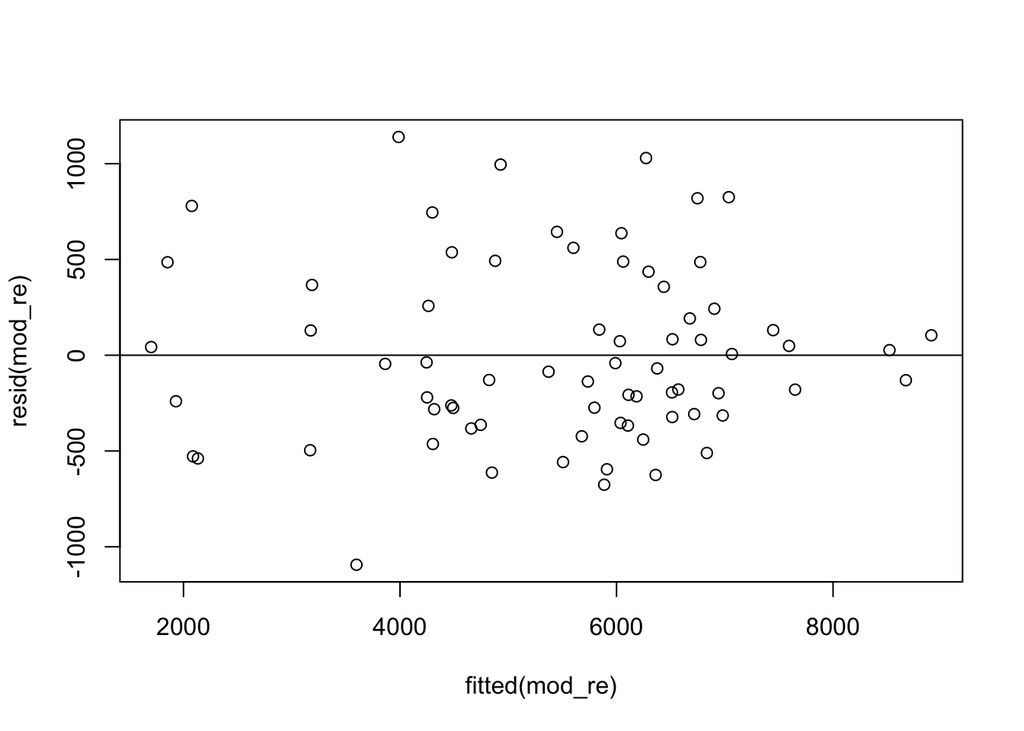

```r
plot(resid(mod_re) ~ fitted(mod_re))
abline(h = 0)
```

```r
#Review contribution of each random effect and their predictors (BLUPs)
summary(mod_re)$varcor
```

```
##  Groups       Name        Std.Dev.
##  rep:mainplot (Intercept) 225.511719
##  rep          (Intercept)   0.055412
##  Residual                 591.135787
```

```r
ranef(mod_re)$rep
```

```
##        (Intercept)
## rep1 -1.452121e-05
## rep2  2.286110e-05
## rep3 -8.339886e-06
```

```r
ranef(mod_re)$`rep:mainplot`
```

```
##           (Intercept)
## rep1:mp1     9.811810
## rep1:mp2    63.224824
## rep1:mp3  -218.067361
## rep1:mp4   -28.055625
## rep1:mp5  -153.708053
## rep1:mp6    86.282566
## rep2:mp7   116.821795
## rep2:mp8     7.297522
## rep2:mp9  -116.269898
## rep2:mp10   -7.297538
## rep2:mp11  207.335697
## rep2:mp12  170.756061
## rep3:mp13   47.311300
## rep3:mp14 -179.280072
## rep3:mp15   36.886258
## rep3:mp16   -2.514272
## rep3:mp17  -70.522346
## rep3:mp18   29.987332
```

#### Mean Comparisons and Data Visualization

Here we have multiple random effects - replicate and mainplot within replicate.

```r
library(emmeans)
library(multcomp)
mod_re %>% car::Anova(type = 3,test.statistic="F")
```

```
## Analysis of Deviance Table (Type III Wald F tests with Kenward-Roger df)
##
## Response: yield
##                    F Df Df.res    Pr(>F)
## (Intercept) 135.5381  1 45.783 2.793e-15 ***
## N            17.6219  5 41.965 2.230e-09 ***
## G             3.0166  3 36.000    0.0424 *
## N:G          13.2360 15 36.000 2.078e-10 ***
## ---
## Signif. codes:  0 '***' 0.001 '**' 0.01 '*' 0.05 '.' 0.1 ' ' 1
```

```r
withinG_mean_comparisons_tukey_re <- mod_re %>%
  emmeans(specs = ~N | G) %>%
  cld(Letters = letters, decreasing = TRUE)
withinG_mean_comparisons_tukey_re
```

```
## G = A:
##  N  emmean  SE   df lower.CL upper.CL .group
##  N6   8701 365 45.8     7965     9436  a
##  N5   7563 365 45.8     6828     8299  ab
##  N4   6733 365 45.8     5997     7468   bc
##  N3   6400 365 45.8     5665     7135   bc
##  N2   5672 365 45.8     4937     6407    cd
##  N1   4253 365 45.8     3517     4988     d
##
## G = B:
##  N  emmean  SE   df lower.CL upper.CL .group
##  N5   6951 365 45.8     6215     7686  a
##  N4   6895 365 45.8     6160     7630  a
##  N6   6540 365 45.8     5805     7276  a
##  N3   6259 365 45.8     5524     6994  a
##  N2   5982 365 45.8     5247     6717  a
##  N1   4306 365 45.8     3571     5041   b
##
## G = C:
##  N  emmean  SE   df lower.CL upper.CL .group
##  N5   6687 365 45.8     5952     7423  a
##  N6   6065 365 45.8     5330     6801  a
##  N4   6014 365 45.8     5279     6749  a
##  N3   5994 365 45.8     5259     6729  a
##  N2   5443 365 45.8     4707     6178  a
##  N1   3177 365 45.8     2442     3913   b
##
## G = D:
##  N  emmean  SE   df lower.CL upper.CL .group
##  N2   4816 365 45.8     4081     5551  a
##  N3   4812 365 45.8     4077     5547  a
##  N1   4481 365 45.8     3746     5217  a
##  N4   3816 365 45.8     3081     4551  a
##  N5   2047 365 45.8     1311     2782   b
##  N6   1881 365 45.8     1145     2616   b
##
## Degrees-of-freedom method: kenward-roger
## Confidence level used: 0.95
## P value adjustment: tukey method for comparing a family of 6 estimates
## significance level used: alpha = 0.05
## NOTE: If two or more means share the same grouping symbol,
##       then we cannot show them to be different.
##       But we also did not show them to be the same.
```

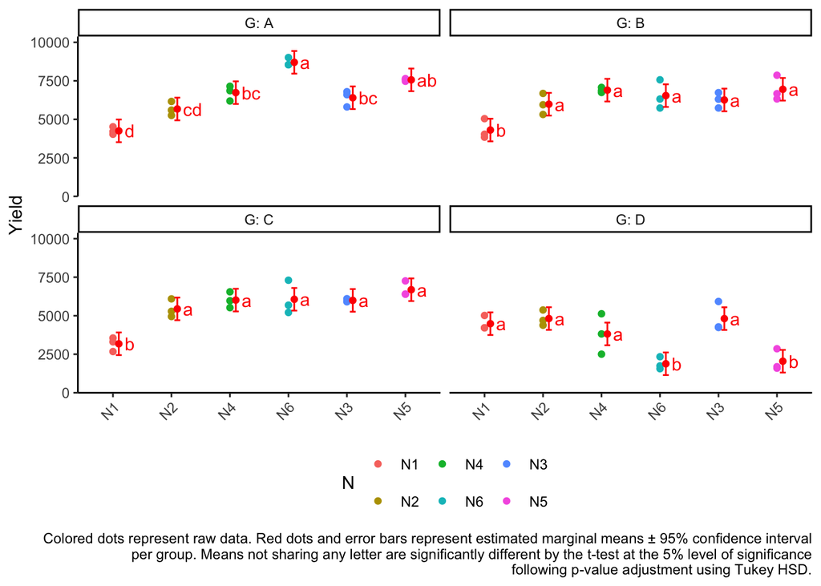

```r
withinG_mean_comparisons_tukey_re <- withinG_mean_comparisons_tukey_re %>%
  as_tibble() %>%
  mutate(N_G = paste0(N, "-", G)) %>%
  mutate(N_G = fct_reorder(N_G, emmean))

Split_plot <- Split_plot %>%
  mutate(N_G = paste0(N, "-", G)) %>%
  mutate(N_G = fct_relevel(N_G, levels(withinG_mean_comparisons_tukey_re$N_G)))

withinG_RCBD_Plot_tukey <- ggplot() +
  facet_wrap(~G, labeller = label_both) + #facet per G level
  geom_point(data = Split_plot, aes(y = yield, x = N, color = N)) +
  geom_point(data = withinG_mean_comparisons_tukey_re, aes(y = emmean, x = N), color = "red", position = position_nudge(x = 0.1)) +
  geom_errorbar(data = withinG_mean_comparisons_tukey_re, aes(ymin = lower.CL, ymax = upper.CL, x = N), color = "red", width = 0.1, position = position_nudge(x = 0.1)) +
  geom_text(data = withinG_mean_comparisons_tukey_re,aes(y = emmean, x = N, label = str_trim(.group)), color = "red", position=position_nudge(x = 0.2), hjust = 0) +
  scale_y_continuous(name = "Yield", limits = c(0, NA), expand = expansion(mult = c(0,0.1))) +
  scale_x_discrete(name = NULL) +
  theme_classic() +
labs(caption=str_wrap("Colored dots represent raw data. Red dots and error bars represent estimated marginal means ± 95% confidence interval per group. Means not sharing any letter are significantly different by the t-test at the 5% level of significance following p-value adjustment using Tukey HSD.", width = 120))+
  theme(axis.text.x = element_text(angle = 45, hjust = 1, vjust = 1), legend.position = "bottom")
withinG_RCBD_Plot_tukey
```

```r
ggsave(here("outputs", "Split_Plot.tiff"), withinG_RCBD_Plot_tukey, width = 20, height = 30, units = "cm", dpi = 300)
```

## Repeated Observations - Random Intercept for each Subject

When working with data that has repeated observations you must contend with the lack of independence to produce unbiased estimates. One simple solution is to include a random intercept in the model for each individual or experimental unit that was observed in the study. This accounts for individual differences in the starting point of the response variable while analyzing repeated measurements from each subject.

Note: when there is more complex dependencies of relatedness within the observations this approach may not suffice, and you may need to resort to modeling more complex covariance structures like auto-regressive order 1 (one of the more common options). Review this [source](https://cran.r-project.org/web/packages/glmmTMB/vignettes/covstruct.html) that discuss time series analysis and covariance structures.

#### Loading the Data

In this example dataset eighteen patients participated in a study in which they were allowed only three hours of sleep per night and their reaction time in a specific test was observed. The underlying correlation structure results in observations from the same individual or subject should be more similar than observations between two individuals or subjects. An initial review of the dataset and random intercept model is tested.

Reaction - average reaction time (ms) Days - number of days of sleep deprivation Subject - subject number on which the observation was made

```r
RO_Data <- read_csv(here("data", "Random_Slope_and_Intercept_Model.csv"), col_types = "ddf")
str(RO_Data)
```

```
## spc_tbl_ [180 × 3] (S3: spec_tbl_df/tbl_df/tbl/data.frame)
##  $ Reaction: num [1:180] 250 259 251 321 357 ...
##  $ Days    : num [1:180] 0 1 2 3 4 5 6 7 8 9 ...
##  $ Subject : Factor w/ 18 levels "308","309","310",..: 1 1 1 1 1 1 1 1 1 1 ...
##  - attr(*, "spec")=
##   .. cols(
##   ..   Reaction = col_double(),
##   ..   Days = col_double(),
##   ..   Subject = col_factor(levels = NULL, ordered = FALSE, include_na = FALSE)
##   .. )
##  - attr(*, "problems")=<externalptr>
```

#### Visualizing the Data

We can create a plot for each subject to understand the variation (or lack of independence) in the relationship between reaction time and the number of days each subject experiences sleep deprivation.

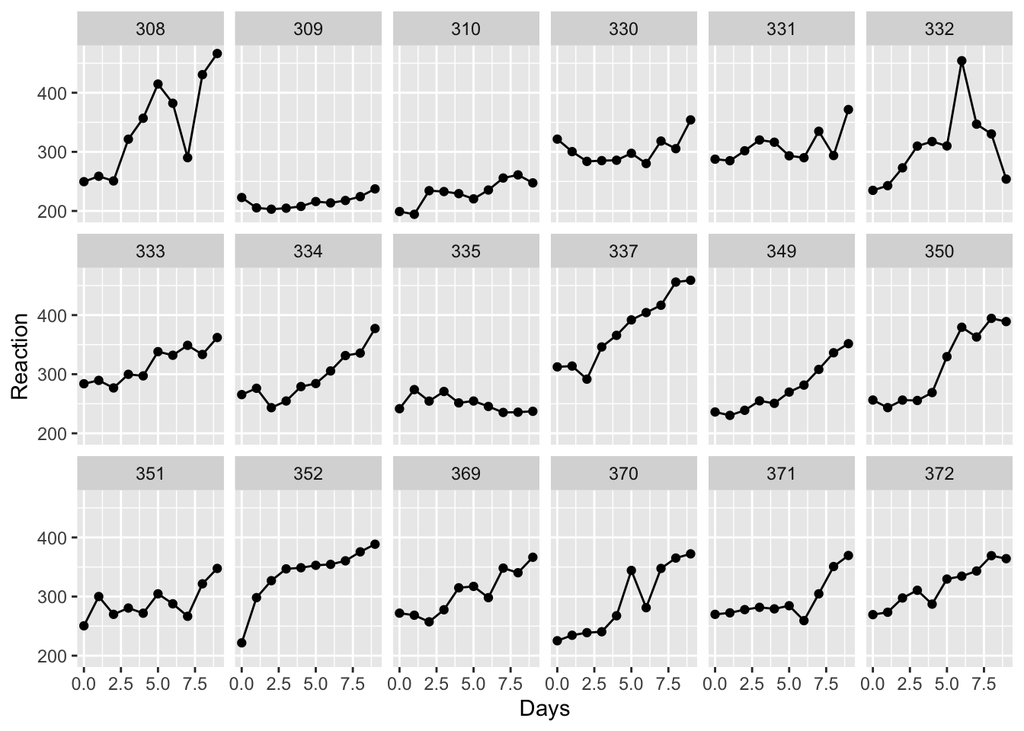

```r
ggplot(RO_Data, aes(y = Reaction, x = Days)) +
    facet_wrap(~ Subject, ncol = 6) +
    geom_point() +
    geom_line()
```

Some lines seem more similar to others, but some a clearly unique. We will compare multiple models to determine how to best fit these data.

#### Fit Linear Model and Test Assumptions

```r
library(lme4) # Used to fit mixed effects models - alternative and precursor to glmmTMB
```

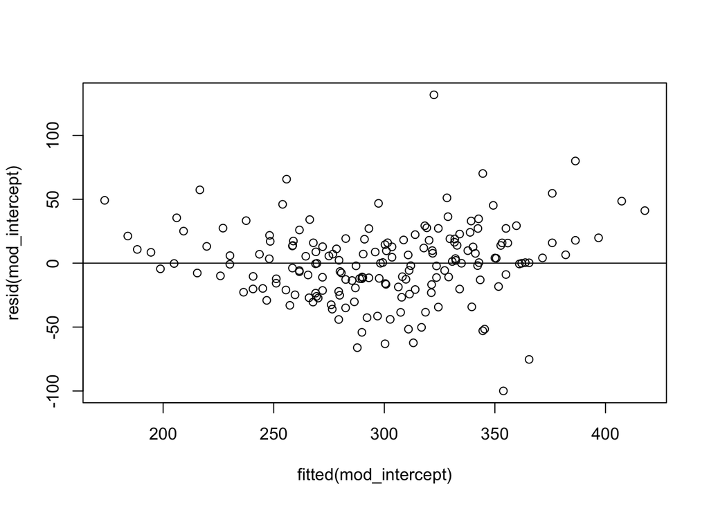

```r
mod_intercept <- lmer(Reaction ~ Days + (1|Subject), data = RO_Data)

#Review model assumptions
plot(resid(mod_intercept) ~ fitted(mod_intercept)) #small hint of curved relationship
abline(h = 0)
```

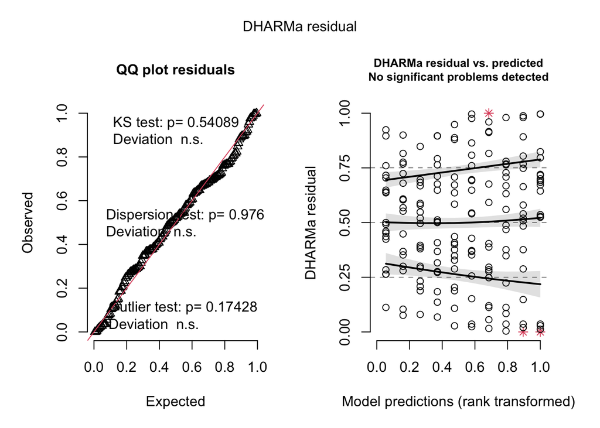

```r
# Using DHARMa residuals
library(DHARMa)
resid <- simulateResiduals(mod_intercept)
plot(resid)
```

#### Interpret Model Results

With mixed effects models you can assess the results from both the fixed effects portion of the model as well as the random effects portion.

```r
#Review contribution of each random effect and their predictors (BLUPs)
summary(mod_intercept)$varcor
```

```
##  Groups   Name        Std.Dev.
##  Subject  (Intercept) 37.124
##  Residual             30.991
```

```r
ranef(mod_intercept)$Subject #unique baseline for each subject
```

```
##     (Intercept)
## 308   40.783710
## 309  -77.849554
## 310  -63.108567
## 330    4.406442
## 331   10.216189
## 332    8.221238
## 333   16.500494
## 334   -2.996981
## 335  -45.282127
## 337   72.182686
## 349  -21.196249
## 350   14.111363
## 351   -7.862221
## 352   36.378425
## 369    7.036381
## 370   -6.362703
## 371   -3.294273
## 372   18.115747
```

```r
car::Anova(mod_intercept, test.statistic = "F") #Days is a continuous variable - summary table gives us the slope of the line
```

```
## Analysis of Deviance Table (Type II Wald F tests with Kenward-Roger df)
##
## Response: Reaction
##          F Df Df.res    Pr(>F)
## Days 169.4  1    161 < 2.2e-16 ***
## ---
## Signif. codes:  0 '***' 0.001 '**' 0.01 '*' 0.05 '.' 0.1 ' ' 1
```

```r
summary(mod_intercept)
```

```
## Linear mixed model fit by REML ['lmerMod']
## Formula: Reaction ~ Days + (1 | Subject)
##    Data: RO_Data
##
## REML criterion at convergence: 1786.5
##
## Scaled residuals:
##     Min      1Q  Median      3Q     Max
## -3.2257 -0.5529  0.0109  0.5188  4.2506
##
## Random effects:
##  Groups   Name        Variance Std.Dev.
##  Subject  (Intercept) 1378.2   37.12
##  Residual              960.5   30.99
## Number of obs: 180, groups:  Subject, 18
##
## Fixed effects:
##             Estimate Std. Error t value
## (Intercept) 251.4051     9.7467   25.79
## Days         10.4673     0.8042   13.02
##
## Correlation of Fixed Effects:
##      (Intr)
## Days -0.371
```

```r
# The output from the summary function given a mixed effects model doesn't give you the p-value, but you can calculate your self.

# The first value is the t value from the model
# The second value is the degrees of freedom for that estimate - the estimate for Days is the slope (1 degree of freedom)
# lower.tail = FALSE provides the test that the given value (t value) is greater than zero (right tailed test).
pt(13.02, 1, lower.tail = FALSE)
```

```
## [1] 0.02439986
```

Each subject has their own baseline for reaction time and the subsequent measurements are relative to their baseline, so a random intercept will allow us to have each subject their unique baseline prediction. To visualize how well this model fits the data, we will plot the predicted values which are lines with y-intercepts that are equal to the sum of the fixed effect of intercept and the random intercept per subject. The slope for each patient is assumed to be the same and is 10.4673.

#### Figure to Explain Results

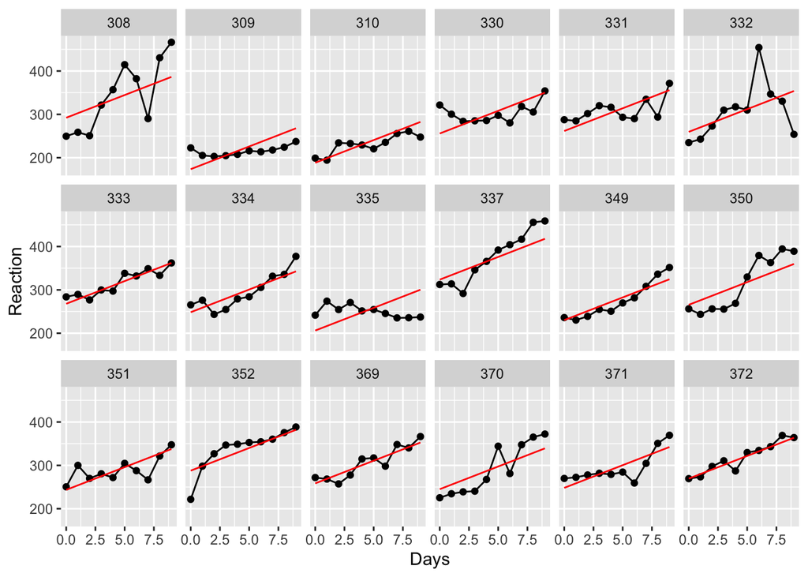

```r
RO_Data <- RO_Data %>%
  mutate(yhat = predict(mod_intercept, re.form = ~(1|Subject))) #predict function calculated predictions based on model estimates and the re.form calculates the random intercepts
ggplot(RO_Data, aes(y = Reaction, x = Days)) +
    facet_wrap(~ Subject, ncol = 6) +
    geom_point() +
    geom_line() + #original lines from raw data
    geom_line(aes(y = yhat), color = 'red') #predicted lines from yhat values
```

Some subjects have less deviation from their predicted lines, but this assumes each subject has the same slope. We can fit a model that allows for each subject to have their own slope as well as their own y-intercept. The random slope will be calculated as a fixed effect of slope plus a random offset from that.

## Repeated Observations - Random Slope and Intercept

#### Fit Linear Model and Test Assumptions

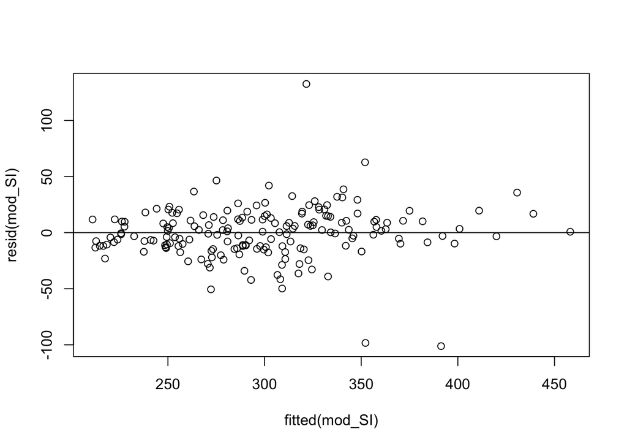

```r
mod_SI <- lmer(Reaction ~ Days + (1 + Days|Subject), data = RO_Data)

#Review model assumptions
plot(resid(mod_SI) ~ fitted(mod_SI)) #curved relationship is no longer - some extreme observations??
abline(h=0)
```

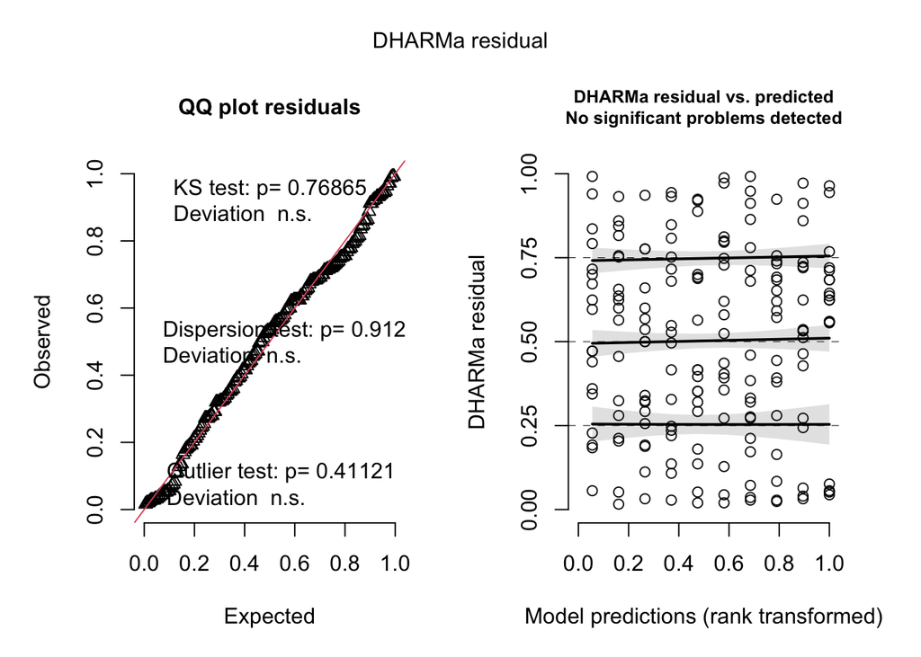

```r
# Using DHARMa residuals
library(DHARMa)
resid <- simulateResiduals(mod_SI)
plot(resid)
```

#### Interpret Model Restuls

```r
#Review contribution of each random effect and their predictors (BLUPs)
summary(mod_SI)$varcor
```

```
##  Groups   Name        Std.Dev. Corr
##  Subject  (Intercept) 24.7407
##           Days         5.9221  0.066
##  Residual             25.5918
```

```r
ranef(mod_SI)$Subject #unique baseline and slope for each subject
```

```
##     (Intercept)        Days
## 308   2.2585509   9.1989758
## 309 -40.3987381  -8.6196806
## 310 -38.9604090  -5.4488565
## 330  23.6906196  -4.8143503
## 331  22.2603126  -3.0699116
## 332   9.0395679  -0.2721770
## 333  16.8405086  -0.2236361
## 334  -7.2326151   1.0745816
## 335  -0.3336684 -10.7521652
## 337  34.8904868   8.6282652
## 349 -25.2102286   1.1734322
## 350 -13.0700342   6.6142178
## 351   4.5778642  -3.0152621
## 352  20.8636782   3.5360011
## 369   3.2754656   0.8722149
## 370 -25.6129993   4.8224850
## 371   0.8070461  -0.9881562
## 372  12.3145921   1.2840221
```

```r
car::Anova(mod_SI, test.statistic = "F") #Days is a continuous variable - summary table gives us the slope of the line
```

```
## Analysis of Deviance Table (Type II Wald F tests with Kenward-Roger df)
##
## Response: Reaction
##           F Df Df.res    Pr(>F)
## Days 45.853  1     17 3.264e-06 ***
## ---
## Signif. codes:  0 '***' 0.001 '**' 0.01 '*' 0.05 '.' 0.1 ' ' 1
```

```r
summary(mod_SI) #estimate for slope (Days) doesn't change much
```

```
## Linear mixed model fit by REML ['lmerMod']
## Formula: Reaction ~ Days + (1 + Days | Subject)
##    Data: RO_Data
##
## REML criterion at convergence: 1743.6
##
## Scaled residuals:
##     Min      1Q  Median      3Q     Max
## -3.9536 -0.4634  0.0231  0.4634  5.1793
##
## Random effects:
##  Groups   Name        Variance Std.Dev. Corr
##  Subject  (Intercept) 612.10   24.741
##           Days         35.07    5.922   0.07
##  Residual             654.94   25.592
## Number of obs: 180, groups:  Subject, 18
##
## Fixed effects:
##             Estimate Std. Error t value
## (Intercept)  251.405      6.825  36.838
## Days          10.467      1.546   6.771
##
## Correlation of Fixed Effects:
##      (Intr)
## Days -0.138
```

Review figure of each subject with their unique slope and intercept

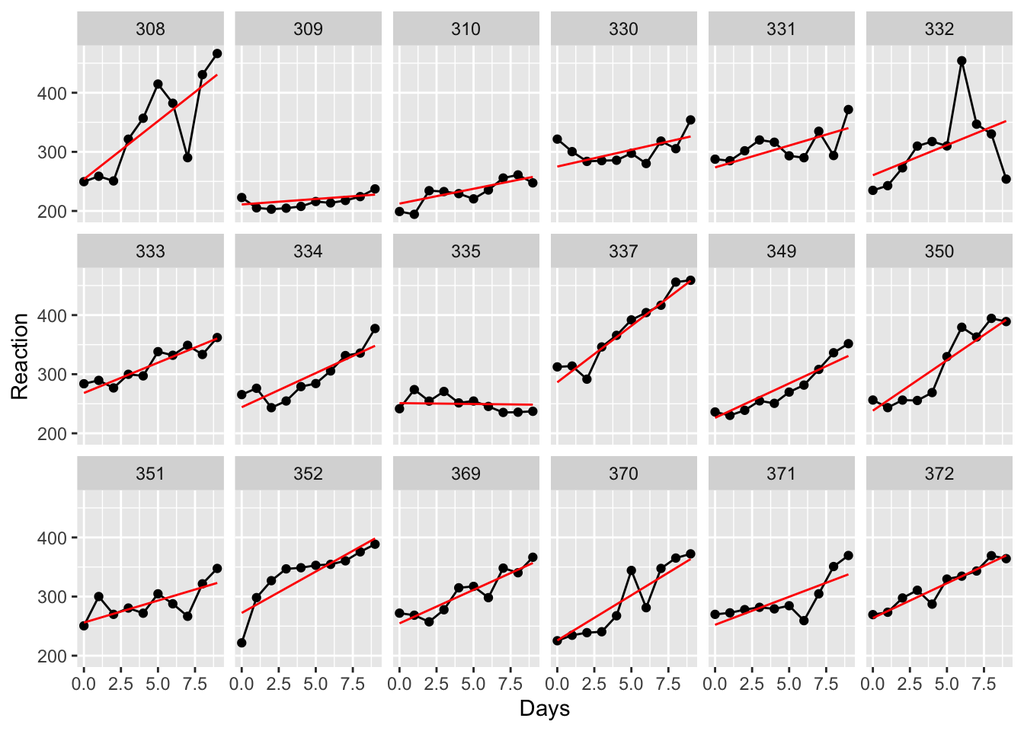

```r
RO_Data <- RO_Data %>%
  mutate(yhat = predict(mod_SI, re.form = ~(1 + Days|Subject)))
ggplot(RO_Data, aes(y = Reaction, x = Days)) +
    facet_wrap(~ Subject, ncol = 6) +
    geom_point() +
    geom_line() +
    geom_line(aes(y = yhat), color = 'red')
```

We have an eye-ball test that tells us the random slope and intercept prediction lines fit the data better. We can employ a formal test to compare the fitness of each model (random intercept and random slope+intercept).

```r
anova(mod_intercept, mod_SI)
```

```
## refitting model(s) with ML (instead of REML)
```

```
## Data: RO_Data
## Models:
## mod_intercept: Reaction ~ Days + (1 | Subject)
## mod_SI: Reaction ~ Days + (1 + Days | Subject)
##               npar    AIC    BIC  logLik deviance  Chisq Df Pr(>Chisq)
## mod_intercept    4 1802.1 1814.8 -897.04   1794.1
## mod_SI           6 1763.9 1783.1 -875.97   1751.9 42.139  2  7.072e-10 ***
## ---
## Signif. codes:  0 '***' 0.001 '**' 0.01 '*' 0.05 '.' 0.1 ' ' 1
```

The lower AIC and BIC values and the higher (less negative) log-likelihood value tells us that the random slope and intercept model is a better model than just a random intercept model.

We can review the results from the better fitting model with first the population estimate for the relationship between Days and Reaction time. Then the estimates for each subject.

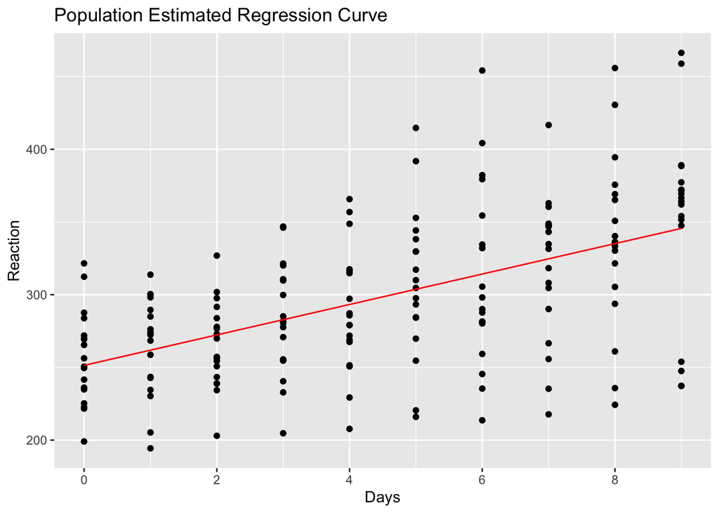

```r
RO_Data <- RO_Data %>%
  mutate(yhat = predict(mod_SI, re.form = ~0))
ggplot(RO_Data, aes(x = Days, y = yhat)) +
  geom_point(aes(x = Days,y = Reaction)) +
  geom_line(color='red') +
  ylab('Reaction') +
  ggtitle('Population Estimated Regression Curve') +
  scale_x_continuous(breaks = seq(0,9, by = 2))
```

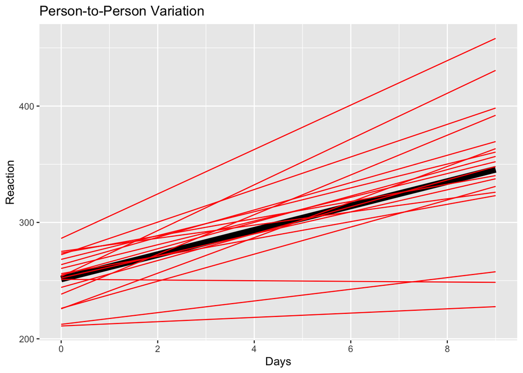

```r
RO_Data <- RO_Data %>%
  mutate(yhat.ind = predict(mod_SI, re.form = ~(1 + Days|Subject)))
ggplot(RO_Data, aes(x = Days)) +
  geom_line(aes(y = yhat), linewidth = 3) +
  geom_line(aes(y = yhat.ind, group = Subject), color = 'red') +
  scale_x_continuous(breaks = seq(0,9, by = 2)) +
  ylab('Reaction') +
  ggtitle('Person-to-Person Variation')
```

The final step in producing a figure that explains the relationship would be to incorporate confidence intervals around the predicted relationship. A familiar approach to produce confidence intervals around prediction line uses the predict function again. This approach may be easier to include other variables from more complex models. Those terms can be added to the expand.grid function.

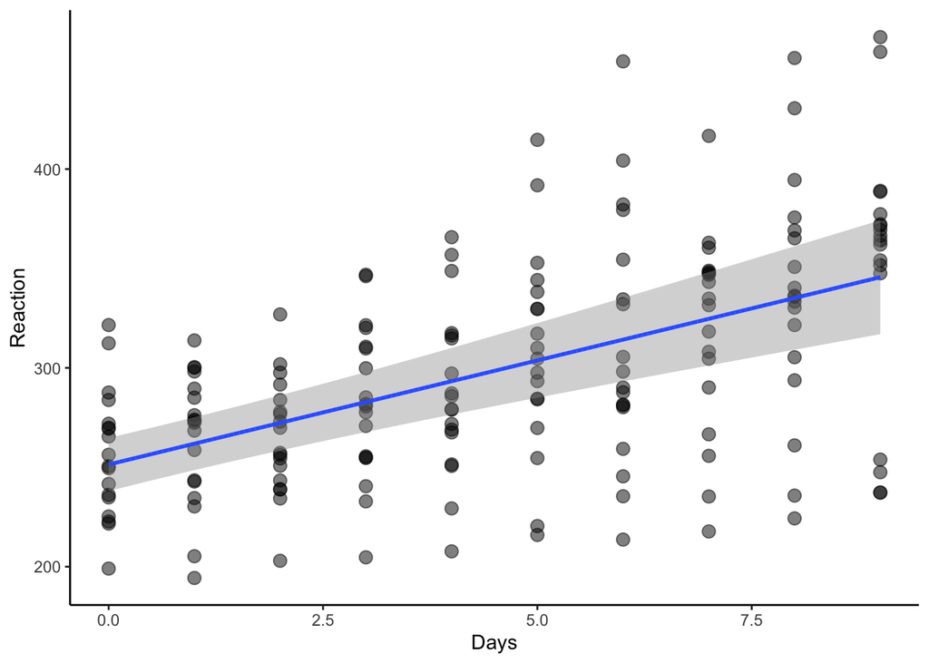

```r
#Find range of values for new body size range
min.days <- min(RO_Data$Days)
max.days <- max(RO_Data$Days)
#New x data
new.x <- expand.grid(Days = seq(min.days, max.days, length = 1000), Subject = levels(RO_Data$Subject))
#Generate fits and standard errors at new.x values
new.y <- predict(mod_SI, newdata = new.x, se.fit = TRUE, re.form = NA)
new.y <- data.frame(new.y)
#housekeeping to put new.x and new.y together
addThese <- data.frame(new.x, new.y)
addThese <- rename(addThese, Reaction = fit)
#Add confidence intervals
addThese <- mutate(addThese, lwr = Reaction - 1.96 * se.fit,
                          upr = Reaction + 1.96 * se.fit)
#See how the confidence intervals match the raw data
ggplot(RO_Data, aes(x = Days, y = Reaction)) +
  geom_point(size = 3, alpha = 0.5) +
  geom_smooth(data = addThese, aes(ymin = lwr, ymax = upr), stat = "identity") +
  theme_classic()
```